# Predicting Recidivism in Boward County, FL

**Team 5: Satvika Neti, Pooja Puvvadi, and Sinduja Sriskanda** **sneti, ppuvvadi, ssriskan**

**1. Introduction**

The use of risk assessments are growing increasingly common in all facets of the legal system nationwide. The objective of this project is to create, evaluate, and validate models that could predict the risk of recidivism within 2 years of a given arrest. The data to build this model will consist of ~60K of criminal charges that was published by ProPublicia.

**1.1 Data Processing**

**Predictors**

The predictors we chose to focus on to determine likelihood of recidivism are based on the following predictors

- sex
- age at time of offense
- race
- juvenile felony count
- juvenile misdemeanor count
- juvenile other count
- priors count
- charge degree
- length of stay in jail
- whether he/she was arrested later on

**Age at the time of offense** was calculated based on the person’s DoB and one of the following dates:

- Time of Offense
- Time of Arrest

**Length of stay** was calculated based on the the time in and our of jail measured in Days. If someone has stayed in jail for less than 24 hours, then it would be indicated as 0 days.

**Decile score** is not included since this score is based on a scale used to determine likelihood of recidivism for COMPAS and would be highly correlated with the demographics we are currently focusing on.

**Charge Degree of O** did not resut in any jail time, and are thereby removed.

Based off ProPublica’s analysis, we also believe not all rows are suitable for analysis. Some rows were removed because of missing data. Additionally, if the charge date of a defendants crime was not within 30 days from when the people was arrested, it is assumed that the right offense canot be guaranteed and to maintain quality of the dataset.

The data was filtered to include rows of those in two years times were either recidivated or outside of the correctional facility.

### DATA CLEANING FOR GENERAL DATASET

```r
#df cleaning for all criminals
subset.score.df <- dplyr::select(compas.score.two.year, sex, dob, age, age_cat, race, c_offense_date, c_arrest_date, juv_fel_count, days_b_screening_arrest, decile_score, juv_misd_count, juv_other_count, priors_count, c_jail_in, c_jail_out,c_charge_degree, is_recid, score_text)

subset.score.df %>%
  filter(days_b_screening_arrest <= 30) %>%
  filter(days_b_screening_arrest >= -30) %>%
  filter(c_charge_degree != "O") %>%
  filter(score_text != 'N/A')
```

```
## # A tibble: 6,172 x 18
##    sex   dob          age age_cat race  c_offense_date c_arrest_date
##    <chr> <date>     <dbl> <chr>   <chr> <date>         <date>
##  1 Male  1947-04-18    69 Greate~ Other 2013-08-13     NA
##  2 Male  1982-01-22    34 25 - 45 Afri~ 2013-01-26     NA
##  3 Male  1991-05-14    24 Less t~ Afri~ 2013-04-13     NA
##  4 Male  1971-08-22    44 25 - 45 Other 2013-11-30     NA
##  5 Male  1974-07-23    41 25 - 45 Cauc~ 2014-02-18     NA
##  6 Male  1973-02-25    43 25 - 45 Other NA             2013-08-29
##  7 Fema~ 1976-06-03    39 25 - 45 Cauc~ 2014-03-15     NA
##  8 Male  1988-06-01    27 25 - 45 Cauc~ 2013-11-25     NA
##  9 Male  1992-08-18    23 Less t~ Afri~ 2013-10-03     NA
## 10 Fema~ 1978-08-22    37 25 - 45 Cauc~ 2013-01-01     NA
## # ... with 6,162 more rows, and 11 more variables: juv_fel_count <dbl>,
## #   days_b_screening_arrest <dbl>, decile_score <dbl>,
## #   juv_misd_count <dbl>, juv_other_count <dbl>, priors_count <dbl>,
## #   c_jail_in <dttm>, c_jail_out <dttm>, c_charge_degree <chr>,
## #   is_recid <dbl>, score_text <chr>
```

```r
#add new column to indicate length of stay in jail
subset.score.df$stay <- as.numeric(as.Date(subset.score.df$c_jail_out)
                                - as.Date(subset.score.df$c_jail_in))
subset.score.df$stay[is.na(subset.score.df$stay)] = 0

#create age of arrest column
subset.score.df$age_offense <- as.numeric(as.Date(subset.score.df$c_offense_date) - as.Date(subset.score.df$dob))
subset.score.df$age_offense <- round(subset.score.df$age_offense/365)

#change categorphy demographics if needed
subset.score.df <- mutate(subset.score.df, age_cat= ifelse(age_offense %in% 0:24, "Less than 25",
                                                 ifelse(age_offense %in% 25:45, "25 - 45",
                                                        "Greater than 45")))

#change certain columns into factor
subset.score.df$c_charge_degree <- factor(subset.score.df$c_charge_degree, levels = c("M", "F"))
subset.score.df$age_cat <- factor(subset.score.df$age_cat,
                                  levels = c("Less than 25" , "25 - 45" , "Greater than 45"))
subset.score.df$race <- factor(subset.score.df$race)
subset.score.df$sex <- factor(subset.score.df$sex, levels = c("Male", "Female"))
subset.score.df$is_recid <- factor(subset.score.df$is_recid, levels = c("0", "1"))

#raw.score.df selects predictors that would be considered

raw.score.df <- subset.score.df[,-c(2,3,6,7,9,10,14,15,18,20)]
```

### DATA CLEANING FOR VIOLENT DATASET

```r
#df cleaning for all criminals
violent.subset.score.df <- dplyr::select(compas.score.violent, sex, dob, age, age_cat, race, c_offense_date, c_arrest_date, juv_fel_count, days_b_screening_arrest, decile_score, juv_misd_count, juv_other_count, priors_count, c_jail_in, c_jail_out,c_charge_degree, is_recid, is_violent_recid, score_text)

violent.subset.score.df %>%
  filter(days_b_screening_arrest <= 30) %>%
  filter(days_b_screening_arrest >= -30) %>%
  filter(c_charge_degree != "O") %>%
  filter(score_text != 'N/A')
```

```
## # A tibble: 4,015 x 19
##    sex   dob          age age_cat race  c_offense_date c_arrest_date
##    <chr> <date>     <dbl> <chr>   <chr> <date>         <date>
##  1 Male  1947-04-18    69 Greate~ Other 2013-08-13     NA
##  2 Male  1982-01-22    34 25 - 45 Afri~ 2013-01-26     NA
##  3 Male  1971-08-22    44 25 - 45 Other 2013-11-30     NA
##  4 Male  1973-02-25    43 25 - 45 Other NA             2013-08-29
##  5 Fema~ 1976-06-03    39 25 - 45 Cauc~ 2014-03-15     NA
##  6 Male  1988-06-01    27 25 - 45 Cauc~ 2013-11-25     NA
##  7 Fema~ 1978-08-22    37 25 - 45 Cauc~ 2013-01-01     NA
##  8 Male  1974-12-02    41 25 - 45 Afri~ 2013-10-08     NA
##  9 Male  1979-01-25    37 25 - 45 Hisp~ 2014-03-24     NA
## 10 Male  1990-06-22    25 25 - 45 Afri~ 2013-12-21     NA
## # ... with 4,005 more rows, and 12 more variables: juv_fel_count <dbl>,
## #   days_b_screening_arrest <dbl>, decile_score <dbl>,
## #   juv_misd_count <dbl>, juv_other_count <dbl>, priors_count <dbl>,
## #   c_jail_in <dttm>, c_jail_out <dttm>, c_charge_degree <chr>,
## #   is_recid <dbl>, is_violent_recid <dbl>, score_text <chr>
```

```r
#add new column to indicate length of stay in jail
violent.subset.score.df$stay <- as.numeric(as.Date(violent.subset.score.df$c_jail_out)
                                - as.Date(violent.subset.score.df$c_jail_in))
violent.subset.score.df$stay[is.na(violent.subset.score.df$stay)] = 0

#create age of arrest column
violent.subset.score.df$age_offense <- as.numeric(as.Date(violent.subset.score.df$c_offense_date) - as.Date(violent.subset.score.df$dob))
violent.subset.score.df$age_offense <- round(violent.subset.score.df$age_offense/365)

#change categorphy demographics if needed
violent.subset.score.df <- mutate(violent.subset.score.df, age_cat= ifelse(age_offense %in% 0:24, "Less than 25",
                                                 ifelse(age_offense %in% 25:45, "25 - 45",
                                                        "Greater than 45")))

#change certain columns into factor
violent.subset.score.df$c_charge_degree <- factor(violent.subset.score.df$c_charge_degree, levels = c("M", "F"))
violent.subset.score.df$age_cat <- factor(violent.subset.score.df$age_cat,
                                  levels = c("Less than 25" , "25 - 45" , "Greater than 45"))
violent.subset.score.df$race <- factor(violent.subset.score.df$race)
violent.subset.score.df$sex <- factor(violent.subset.score.df$sex, levels = c("Female", "Male"))
violent.subset.score.df$is_violent_recid <- factor(violent.subset.score.df$is_violent_recid, levels = c("0", "1"))

#raw.score.violent.df selects predictors that would be considered
raw.score.violent.df <- violent.subset.score.df[,-c(2,3,6,7,9,10,14,15,17,19,21)]
```

**1.2 Training & Test Splits**

**Part 1: General Recidivism**

```r
set.seed(981)

# Upsample the data to artifically overcome sample imbalance
raw.score.df.more.idx <- sample(which(raw.score.df$is_recid == 1), 15000, replace = TRUE)
raw.score.df.upsample <- rbind(raw.score.df,
                            raw.score.df[raw.score.df.more.idx, ])

# Randomly select 20% of the data to be held out for model validation
test.indexes <- sample(1:nrow(raw.score.df.upsample),
                       round(0.2 * nrow(raw.score.df.upsample)))
train.indexes <- setdiff(1:nrow(raw.score.df.upsample), test.indexes)

# Just pull the covariates available to marketers
raw.score.df.train <- raw.score.df.upsample[train.indexes, ]
raw.score.df.test <- raw.score.df.upsample[test.indexes, ]
```

**Part 2: Violent Recidivism**

```r
set.seed(981)

# Upsample the data to artifically overcome sample imbalance
raw.score.violent.df.more.idx <- sample(which(raw.score.violent.df$is_violent_recid == 1), 15000, replace = TRUE)
raw.score.violent.df.upsample <- rbind(raw.score.violent.df,
                            raw.score.violent.df[raw.score.violent.df.more.idx, ])

# Randomly select 20% of the data to be held out for model validation
test.indexes <- sample(1:nrow(raw.score.violent.df.upsample),
                       round(0.2 * nrow(raw.score.violent.df.upsample)))
train.indexes <- setdiff(1:nrow(raw.score.violent.df.upsample), test.indexes)

# Just pull the covariates available to marketers
raw.score.violent.df.train <- raw.score.violent.df.upsample[train.indexes, ]
raw.score.violent.df.test <- raw.score.violent.df.upsample[test.indexes, ]
```

**2 Exploratory Data Analysis**

In this section, we investgiated our cleaned data to see how recidivism is correlated with different independent variables. This is investigated for both recidivism and violent recidivism. These plots give a brief overview of the demographics of the non-violent cases. As these plots show, the most common groups are Male, African-American, and between 25-45 years old.

**2.1 General Recidivism Independent Analysis** . **2.11 Independent Analysis**

###### Sex

```r
sex_sum <- raw.score.df %>%
  group_by(sex) %>%
  summarize(Count = n())
```

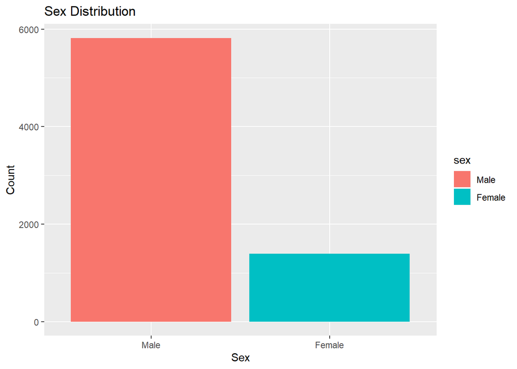

```r
sex_plot = ggplot(data = sex_sum, aes(x = sex, y = Count, fill = sex)) +
  geom_bar(stat = "identity", position = "dodge") +
  labs(title = "Sex Distribution", x = "Sex", y = "Count")

sex_plot
```

###### Race

```r
race_sum <- raw.score.df %>%
  group_by(race) %>%
  summarize(Count = n())
```

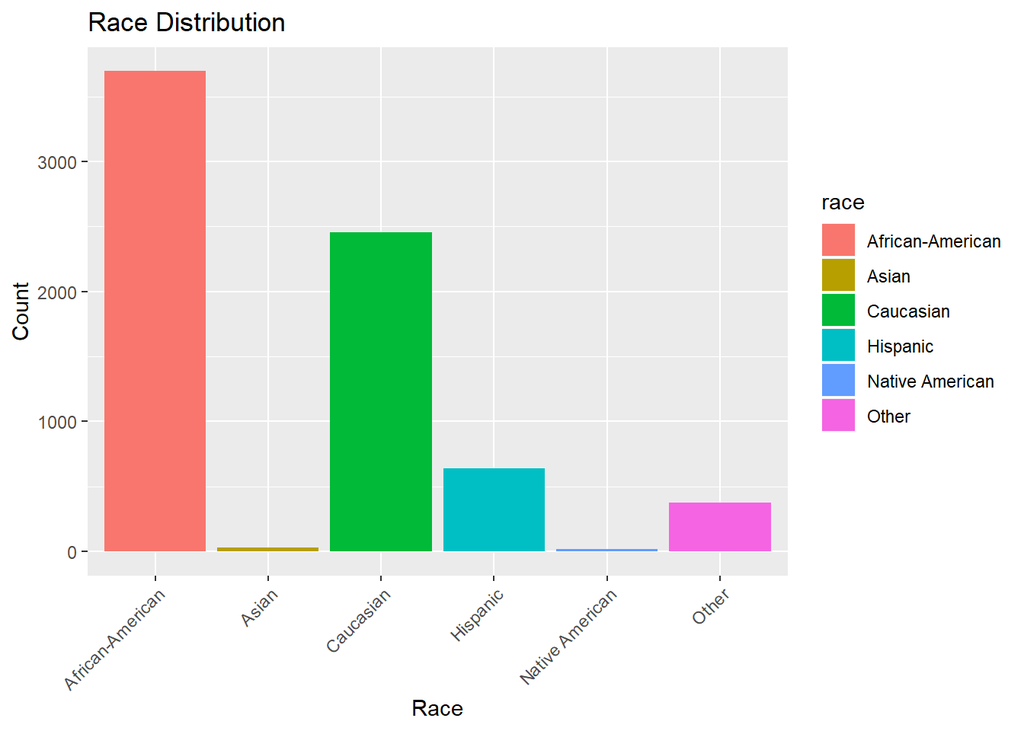

```r
race_plot = ggplot(data = race_sum, aes(x = race, y = Count, fill = race)) +
  geom_bar(stat = "identity", position = "dodge") +
  labs(title = "Race Distribution", x = "Race", y = "Count") +
  theme(axis.text.x = element_text(angle = 45, vjust = 1, hjust = 1))

race_plot
```

###### Age

```r
age_sum <- raw.score.df %>%
  group_by(age_cat) %>%
  summarize(Count = n())
```

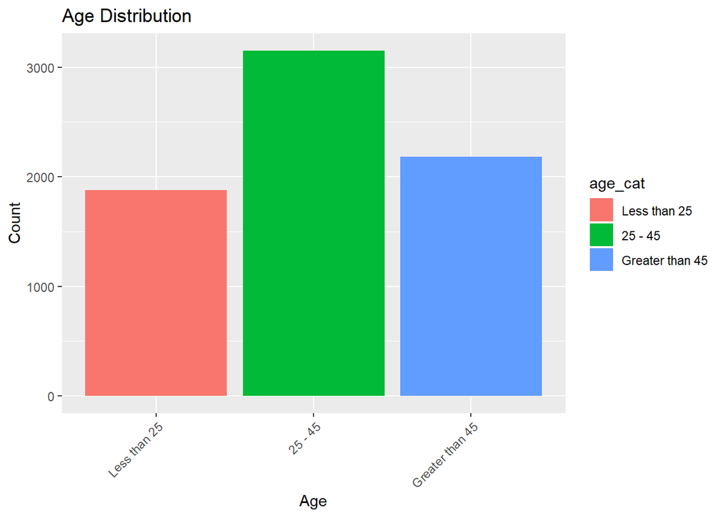

```r
age_plot = ggplot(data = age_sum, aes(x = age_cat, y = Count, fill = age_cat)) +
  geom_bar(stat = "identity", position = "dodge") +
  labs(title = "Age Distribution", x = "Age", y = "Count") +
  theme(axis.text.x = element_text(angle = 45, vjust = 1, hjust = 1))

age_plot
```

**2.12 Bivariate Analysis**

These plots show the relationship between the recidivism rates and the other variables.

###### Sex vs. Recidivism

```r
sex_recid_sum <- raw.score.df %>%
  group_by(is_recid, sex) %>%
  summarize(Count = n())
```

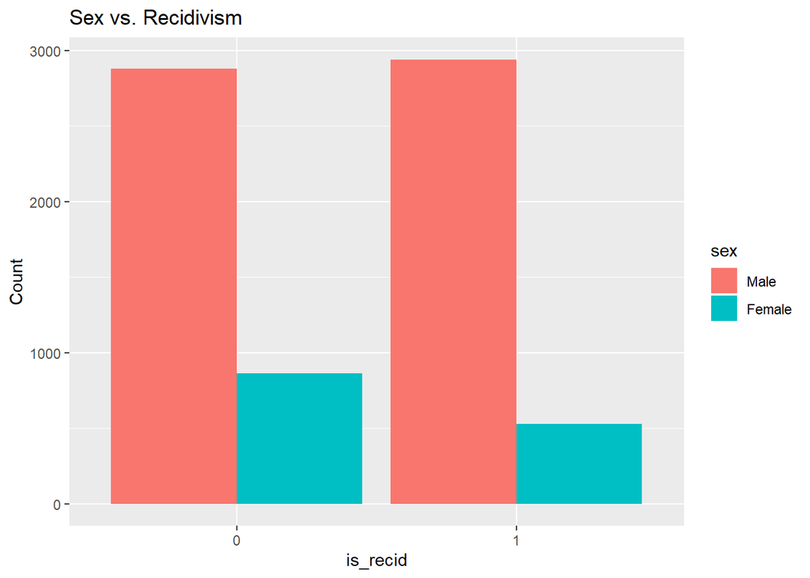

```r
sex_recid_plot = ggplot(data = sex_recid_sum, aes(x = is_recid, y = Count, fill = sex)) +
  geom_bar(stat = "identity", position = "dodge") +
  labs(title = "Sex vs. Recidivism", x = "is_recid", y = "Count")

sex_recid_plot
```

Females had a lower percentage of reconviction than males.

###### Age vs. Recidivism

```r
age_recid_sum <- raw.score.df %>%
  group_by(is_recid, age_cat) %>%
  summarize(Count = n())
```

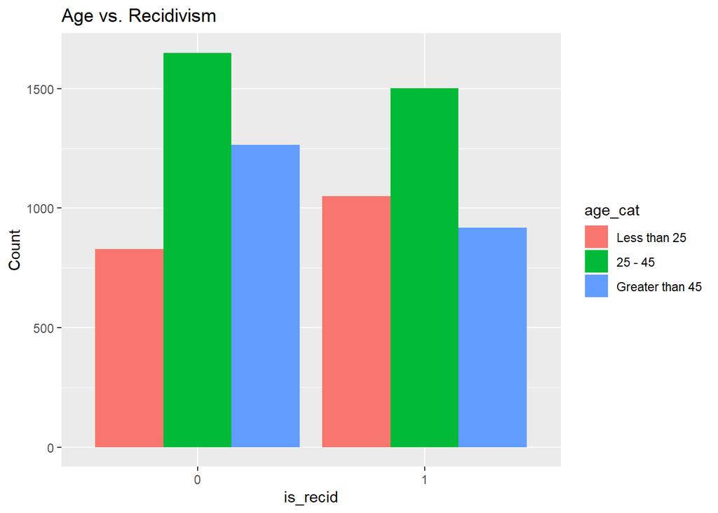

```r
age_recid_plot = ggplot(data = age_recid_sum, aes(x = is_recid, y = Count, fill = age_cat)) +
  geom_bar(stat = "identity", position = "dodge") +
  labs(title = "Age vs. Recidivism", x = "is_recid", y = "Count")

age_recid_plot
```

While a higher percentage of the less than 25 year old age group were reconvicted, the other two categories saw lower percentages of reconviction than that group.

###### Juv_Fel_Count vs. Recidivism

```r
juvf_recid_sum <- raw.score.df %>%
  group_by(Recidivism = as.factor(is_recid)) %>%
  summarize(Juv_Fel = round(mean(juv_fel_count), 2))
```

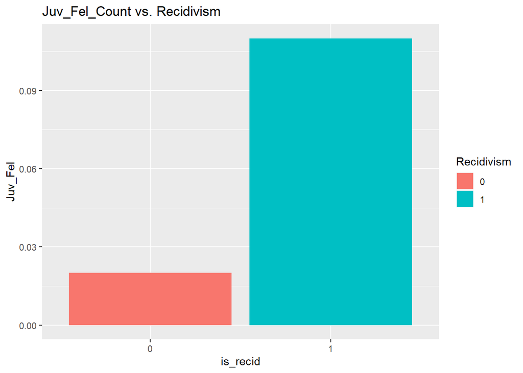

```r
juvf_recid_plot = ggplot(data = juvf_recid_sum, aes(x = Recidivism, y = Juv_Fel, fill = Recidivism)) +
  geom_bar(stat = "identity", position = "dodge") +
  labs(title = "Juv_Fel_Count vs. Recidivism", x = "is_recid", y = "Juv_Fel")

juvf_recid_plot
```

Those in the reconvicted group had a higher juvenile felony count on average.

###### Juv_Misd_Count vs. Recidivism

```r
juvm_recid_sum <- raw.score.df %>%
  group_by(Recidivism = as.factor(is_recid)) %>%
  summarize(Juv_Misd = round(mean(juv_misd_count), 2))
```

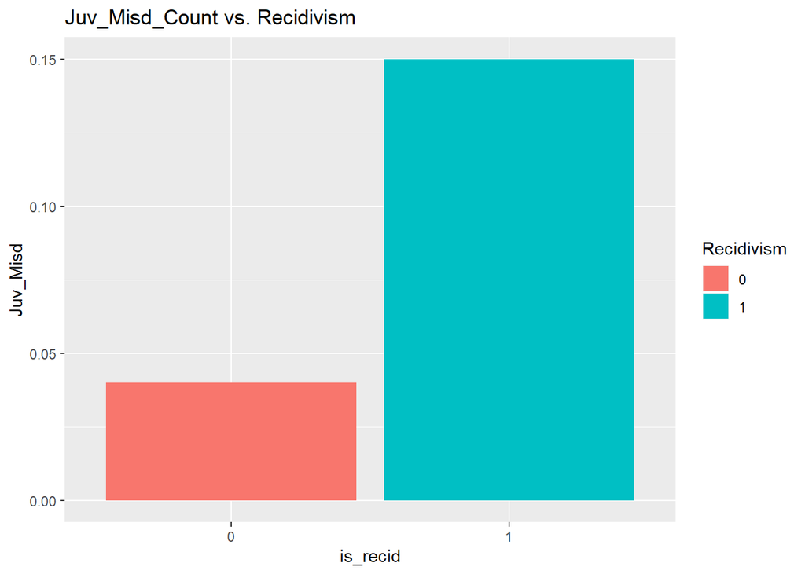

```r
juvm_recid_plot = ggplot(data = juvm_recid_sum, aes(x = Recidivism, y = Juv_Misd, fill = Recidivism)) +
  geom_bar(stat = "identity", position = "dodge") +
  labs(title = "Juv_Misd_Count vs. Recidivism", x = "is_recid", y = "Juv_Misd")

juvm_recid_plot
```

Those in the reconvicted group had a higher juvenile misdemeanor count on average.

###### Juv_Other_Count vs. Recidivism

```r
juvo_recid_sum <- raw.score.df %>%
  group_by(Recidivism = as.factor(is_recid)) %>%
  summarize(Juv_Other = round(mean(juv_other_count), 2))
```

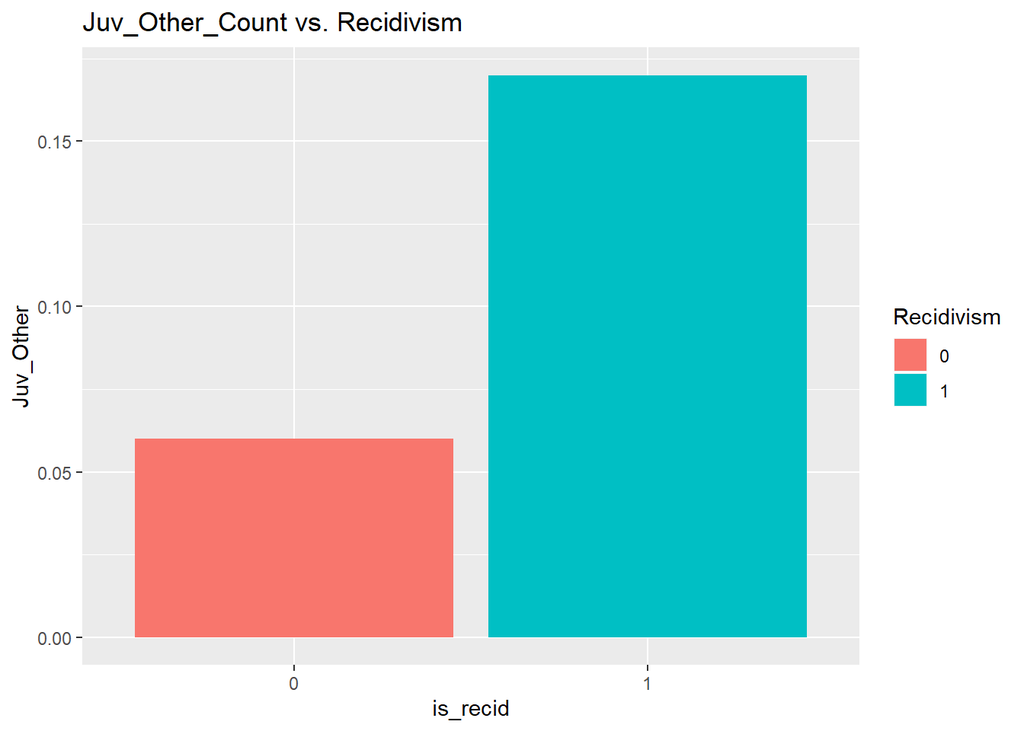

```r
juvo_recid_plot = ggplot(data = juvo_recid_sum, aes(x = Recidivism, y = Juv_Other, fill = Recidivism)) +
  geom_bar(stat = "identity", position = "dodge") +
  labs(title = "Juv_Other_Count vs. Recidivism", x = "is_recid", y = "Juv_Other")

juvo_recid_plot
```

###### Priors_Count vs. Recidivism

```r
priors_recid_sum <- raw.score.df %>%
  group_by(Recidivism = as.factor(is_recid)) %>%
  summarize(Priors = round(mean(priors_count), 2))
```

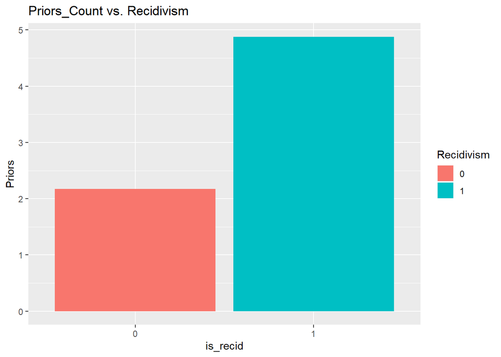

```r
priors_recid_plot = ggplot(data = priors_recid_sum, aes(x = Recidivism, y = Priors, fill = Recidivism)) +
  geom_bar(stat = "identity", position = "dodge") +
  labs(title = "Priors_Count vs. Recidivism", x = "is_recid", y = "Priors")

priors_recid_plot
```

Those in the reconvicted group had a higher priors count on average.

###### c_charge_degree vs. Recidivism

```r
c_recid_sum <- raw.score.df %>%
  group_by(is_recid, c_charge_degree) %>%
  summarize(Count = n())
```

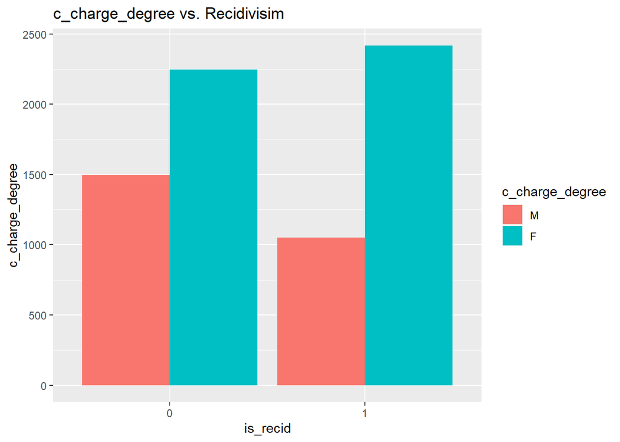

```r
c_recid_plot = ggplot(data = c_recid_sum, aes(x = is_recid, y = Count, fill = c_charge_degree)) +
  geom_bar(stat = "identity", position = "dodge") +
  labs(title = "c_charge_degree vs. Recidivisim", x = "is_recid", y = "c_charge_degree")

c_recid_plot
```

While those who were charged with a misdemeanor had a lower percentage of being reconvicted, those charged with a felony had a higher percentage of being reconvicted.

###### Stay vs. Recidivism

```r
stay_recid_sum <- raw.score.df %>%
  filter(!is.na(stay)) %>%
  group_by(Recidivism = as.factor(is_recid)) %>%
  summarize(Stay = round(mean(stay), 2))
```

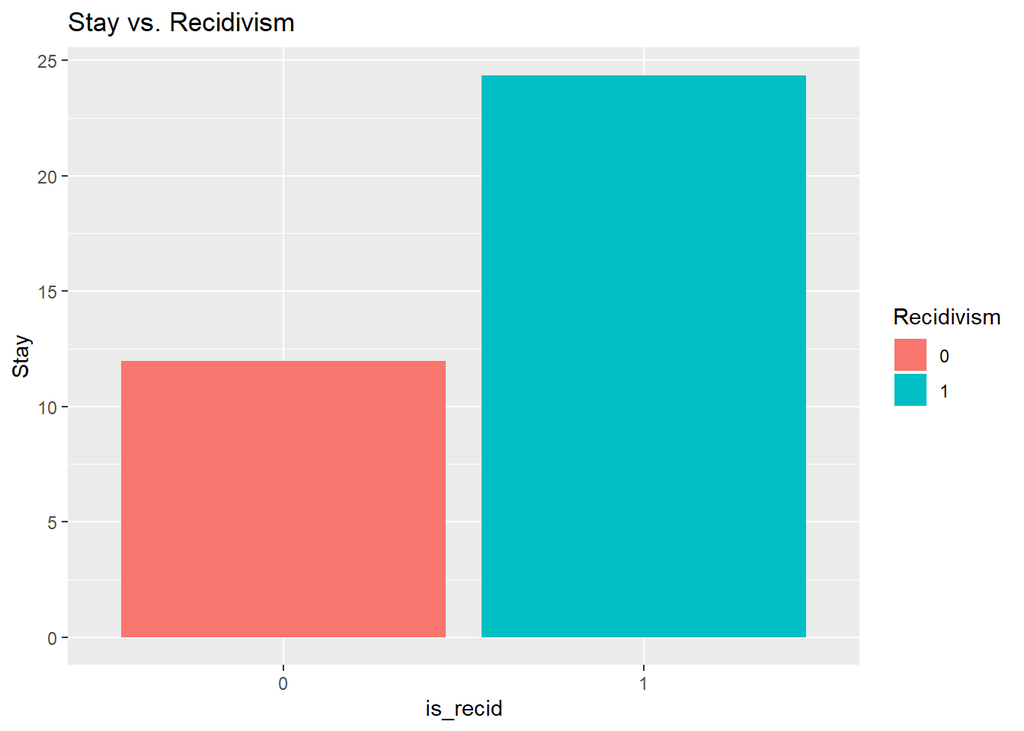

```r
stay_recid_plot = ggplot(data = stay_recid_sum, aes(x = Recidivism, y = Stay, fill = Recidivism)) +
  geom_bar(stat = "identity", position = "dodge") +
  labs(title = "Stay vs. Recidivism", x = "is_recid", y = "Stay")

stay_recid_plot
```

Those in the reconvicted group had a higher length of stay on average.

The next couple of plots show the relationship between demographic information and charge degree.

###### Race vs. c_charge_degree

```r
race_c_sum <- raw.score.df %>%
  group_by(race, c_charge_degree) %>%
  summarize(Count = n())
```

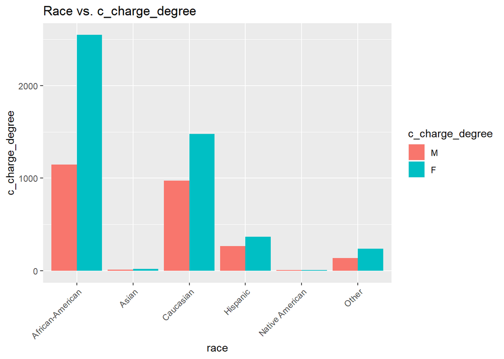

```r
race_c_plot = ggplot(data = race_c_sum, aes(x = race, y = Count, fill = c_charge_degree)) +
  geom_bar(stat = "identity", position = "dodge") +
  labs(title = "Race vs. c_charge_degree", x = "race", y = "c_charge_degree") +
  theme(axis.text.x = element_text(angle = 45, vjust = 1, hjust = 1))

race_c_plot
```

African-Americans had a higher percentage of felonies than the other racial groups.

###### Sex vs. c_charge_degree

```r
sex_c_sum <- raw.score.df %>%
  group_by(sex, c_charge_degree) %>%
  summarize(Count = n())
```

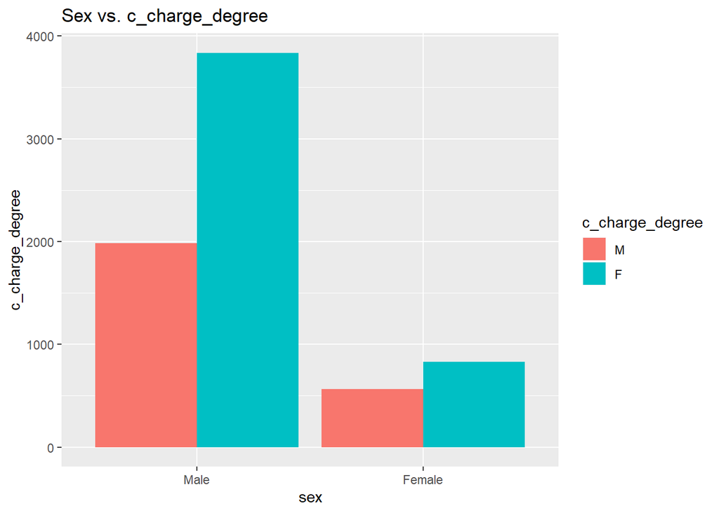

```r
sex_c_plot = ggplot(data = sex_c_sum, aes(x = sex, y = Count, fill = c_charge_degree)) +
  geom_bar(stat = "identity", position = "dodge") +
  labs(title = "Sex vs. c_charge_degree", x = "sex", y = "c_charge_degree")

sex_c_plot
```

Males had a higher percentage of felonies than Females.

**2.2 2-year Violent Recidivism**

**2.21 Indepdent Analysis**

##### Demographics

These plots give a brief overview of the demographics of the violent cases. As these plots show, the most common groups are Male, African-American, and between 25-45 years old, just as in the non-violent case group.

###### Sex

```r
vsex_sum <- raw.score.violent.df %>%
  group_by(sex) %>%
  summarize(Count = n())
```

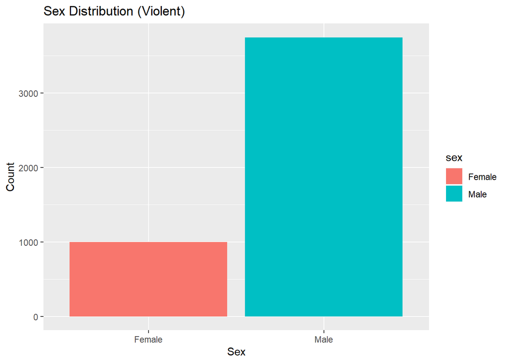

```r
vsex_plot = ggplot(data = vsex_sum, aes(x = sex, y = Count, fill = sex)) +
  geom_bar(stat = "identity", position = "dodge") +
  labs(title = "Sex Distribution (Violent)", x = "Sex", y = "Count")

vsex_plot
```

###### Race

```r
vrace_sum <- raw.score.violent.df %>%
  group_by(race) %>%
  summarize(Count = n())
```

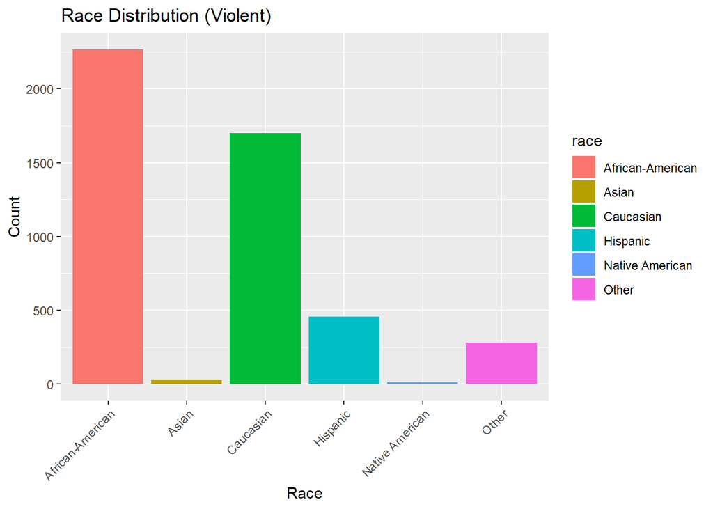

```r
vrace_plot = ggplot(data = vrace_sum, aes(x = race, y = Count, fill = race)) +
  geom_bar(stat = "identity", position = "dodge") +
  labs(title = "Race Distribution (Violent)", x = "Race", y = "Count") +
  theme(axis.text.x = element_text(angle = 45, vjust = 1, hjust = 1))

vrace_plot
```

###### Age

```r
vage_sum <- raw.score.violent.df %>%
  group_by(age_cat) %>%
  summarize(Count = n())
```

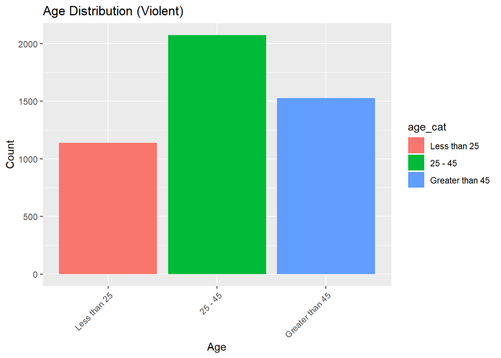

```r
vage_plot = ggplot(data = vage_sum, aes(x = age_cat, y = Count, fill = age_cat)) +
  geom_bar(stat = "identity", position = "dodge") +
  labs(title = "Age Distribution (Violent)", x = "Age", y = "Count") +
  theme(axis.text.x = element_text(angle = 45, vjust = 1, hjust = 1))

vage_plot
```

**2.22 Bivariate Analysis**

These plots show the relationship between the recidivism rates and the other variables.

###### Sex vs. Recidivism

```r
vsex_recid_sum <- raw.score.violent.df %>%
  group_by(is_violent_recid, sex) %>%
  summarize(Count = n())
```

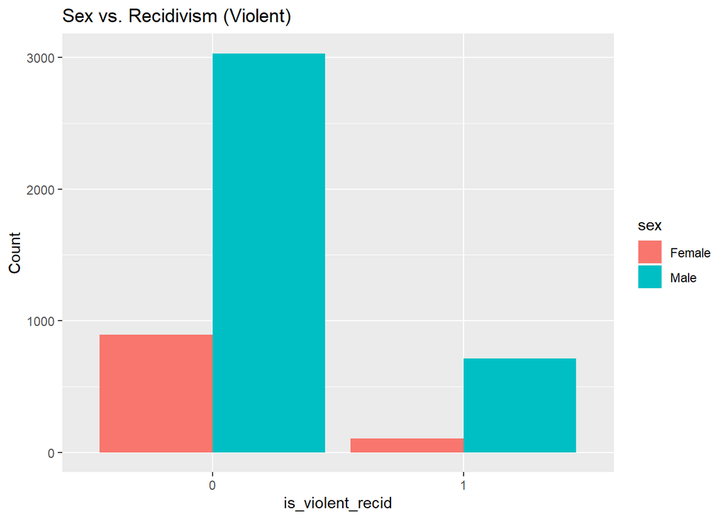

```r
vsex_recid_plot = ggplot(data = vsex_recid_sum, aes(x = is_violent_recid, y = Count, fill = sex)) +
  geom_bar(stat = "identity", position = "dodge") +
  labs(title = "Sex vs. Recidivism (Violent)", x = "is_violent_recid", y = "Count")

vsex_recid_plot
```

Females and males both had a lower percentage of reconviction than no reconviction, unlike in the non-violent cases.

###### Age vs. Recidivism

```r
vage_recid_sum <- raw.score.violent.df %>%
  group_by(is_violent_recid, age_cat) %>%
  summarize(Count = n())
```

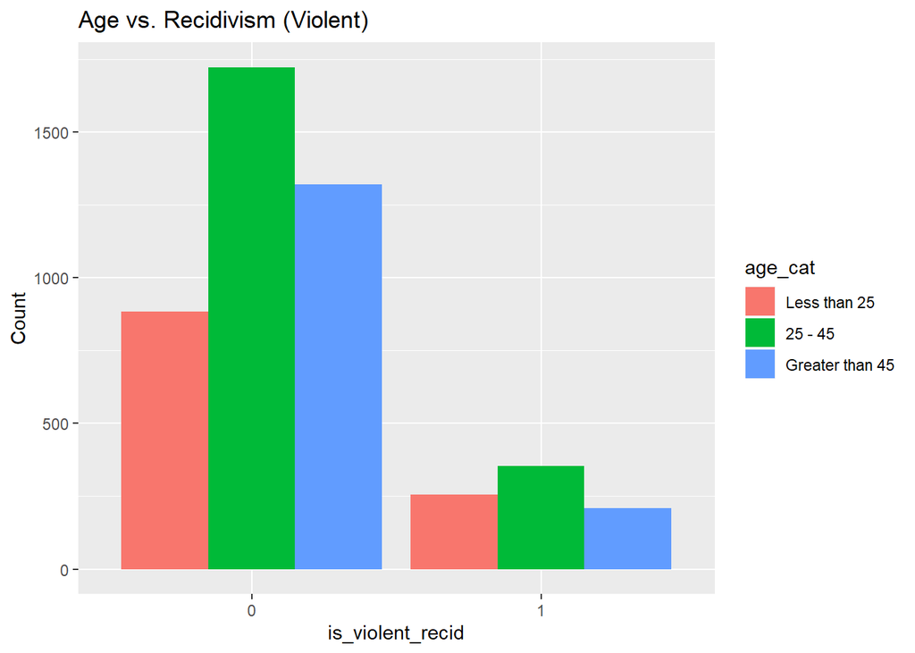

```r
vage_recid_plot = ggplot(data = vage_recid_sum, aes(x = is_violent_recid, y = Count, fill = age_cat)) +
  geom_bar(stat = "identity", position = "dodge") +
  labs(title = "Age vs. Recidivism (Violent)", x = "is_violent_recid", y = "Count")

vage_recid_plot
```

All age categories saw a lower percentage of reconviction than no reconviction, unlike in the non-violent cases.

###### Juv_Fel_Count vs. Recidivism

```r
vjuvf_recid_sum <- raw.score.violent.df %>%
  group_by(Recidivism = as.factor(is_violent_recid)) %>%
  summarize(Juv_Fel = round(mean(juv_fel_count), 2))
```

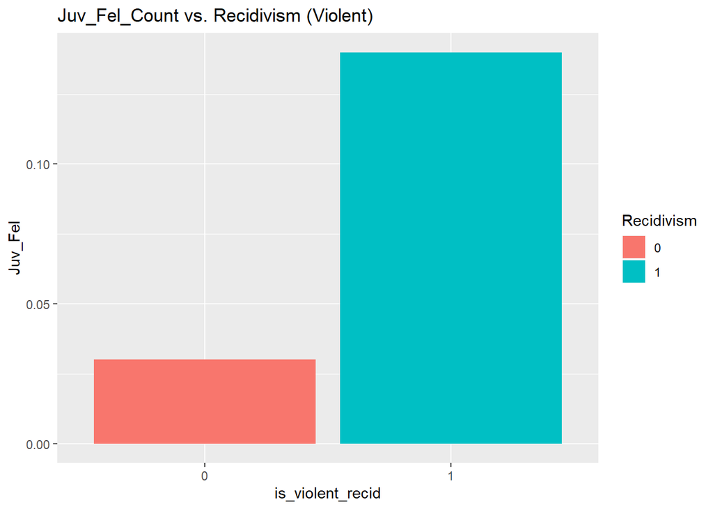

```r
vjuvf_recid_plot = ggplot(data = vjuvf_recid_sum, aes(x = Recidivism, y = Juv_Fel, fill = Recidivism)) +
  geom_bar(stat = "identity", position = "dodge") +
  labs(title = "Juv_Fel_Count vs. Recidivism (Violent)", x = "is_violent_recid", y = "Juv_Fel")

vjuvf_recid_plot
```

Those in the reconvicted group had a higher juvenile felony count on average, just like in the non-violent cases.

###### Juv_Misd_Count vs. Recidivism

```r
vjuvm_recid_sum <- raw.score.violent.df %>%
  group_by(Recidivism = as.factor(is_violent_recid)) %>%
  summarize(Juv_Misd = round(mean(juv_misd_count), 2))
```

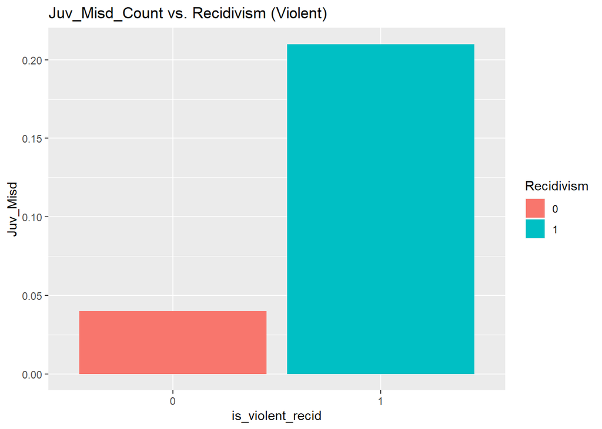

```r
vjuvm_recid_plot = ggplot(data = vjuvm_recid_sum, aes(x = Recidivism, y = Juv_Misd, fill = Recidivism)) +
  geom_bar(stat = "identity", position = "dodge") +
  labs(title = "Juv_Misd_Count vs. Recidivism (Violent)", x = "is_violent_recid", y = "Juv_Misd")

vjuvm_recid_plot
```

Those in the reconvicted group had a higher juvenile misdemeanor count on average, just like in the non-violent cases.

###### Juv_Other_Count vs. Recidivism

```r
vjuvo_recid_sum <- raw.score.violent.df %>%
  group_by(Recidivism = as.factor(is_violent_recid)) %>%
  summarize(Juv_Other = round(mean(juv_other_count), 2))
```

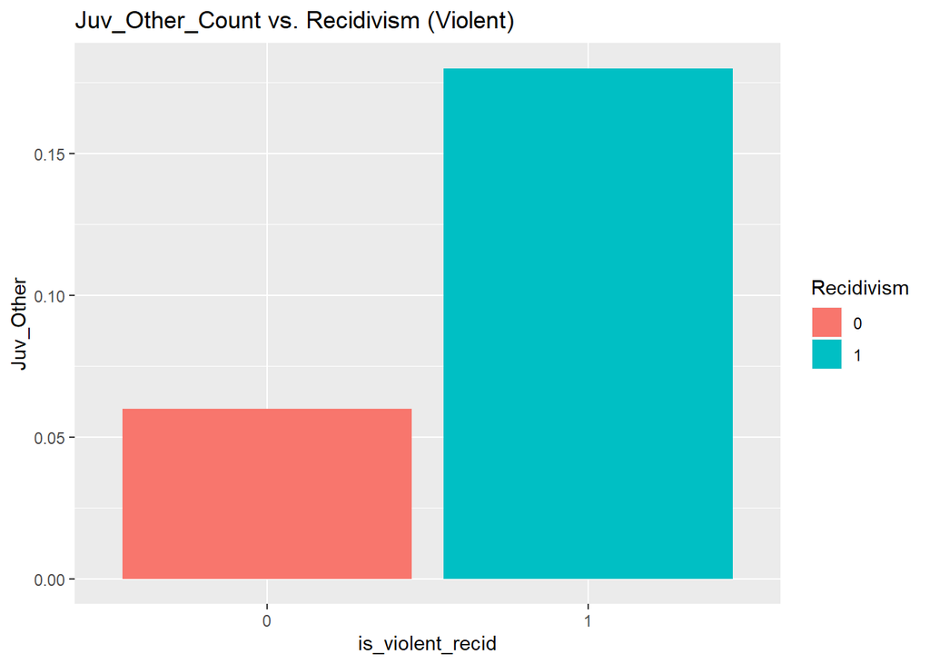

```r
vjuvo_recid_plot = ggplot(data = vjuvo_recid_sum, aes(x = Recidivism, y = Juv_Other, fill = Recidivism)) +
  geom_bar(stat = "identity", position = "dodge") +
  labs(title = "Juv_Other_Count vs. Recidivism (Violent)", x = "is_violent_recid", y = "Juv_Other")

vjuvo_recid_plot
```

###### Priors_Count vs. Recidivism

```r
vpriors_recid_sum <- raw.score.violent.df %>%
  group_by(Recidivism = as.factor(is_violent_recid)) %>%
  summarize(Priors = round(mean(priors_count), 2))
```

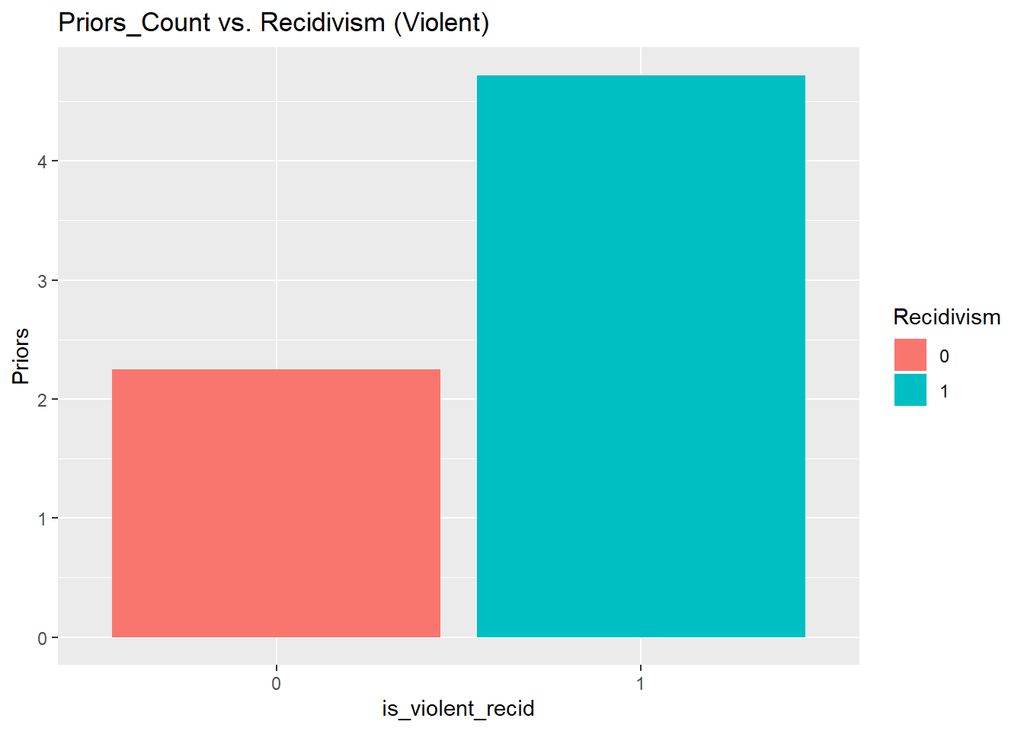

```r
vpriors_recid_plot = ggplot(data = vpriors_recid_sum, aes(x = Recidivism, y = Priors, fill = Recidivism)) +
  geom_bar(stat = "identity", position = "dodge") +
  labs(title = "Priors_Count vs. Recidivism (Violent)", x = "is_violent_recid", y = "Priors")

vpriors_recid_plot
```

Those in the reconvicted group had a higher priors count on average, just like in the non-violent cases.

###### c_charge_degree vs. Recidivism

```r
vc_recid_sum <- raw.score.violent.df %>%
  group_by(is_violent_recid, c_charge_degree) %>%
  summarize(Count = n())
```

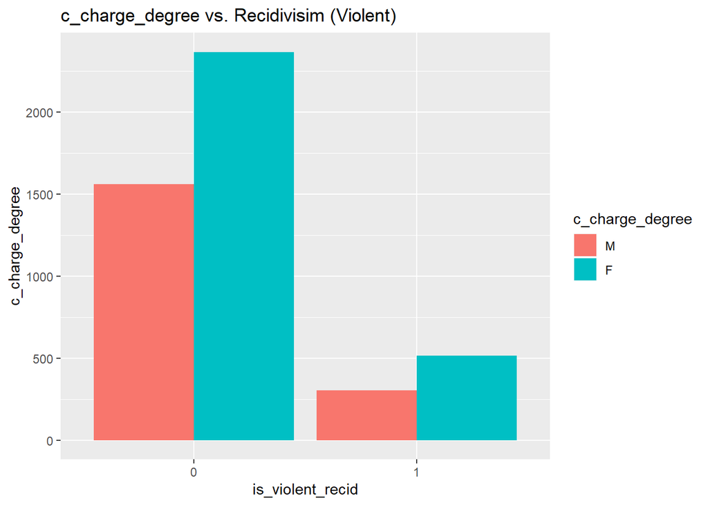

```r
vc_recid_plot = ggplot(data = vc_recid_sum, aes(x = is_violent_recid, y = Count, fill = c_charge_degree)) +
  geom_bar(stat = "identity", position = "dodge") +
  labs(title = "c_charge_degree vs. Recidivisim (Violent)", x = "is_violent_recid", y = "c_charge_degree")

vc_recid_plot
```

Both charge groups had a lower percentage of being reconvicted than not reconvicted, unlike in the non-violent cases.

###### Stay vs. Recidivism

```r
vstay_recid_sum <- raw.score.violent.df %>%
  filter(!is.na(stay)) %>%
  group_by(Recidivism = as.factor(is_violent_recid)) %>%
  summarize(Stay = round(mean(stay), 2))
```

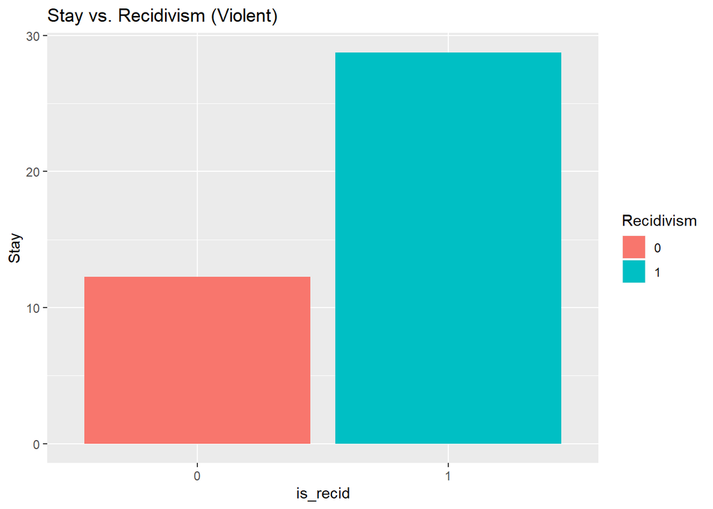

```r
vstay_recid_plot = ggplot(data = vstay_recid_sum, aes(x = Recidivism, y = Stay, fill = Recidivism)) +
  geom_bar(stat = "identity", position = "dodge") +
  labs(title = "Stay vs. Recidivism (Violent)", x = "is_recid", y = "Stay")

vstay_recid_plot
```

Those in the reconvicted group had a higher length of stay on average, just like in the non-violent cases.

The next couple of plots show the relationship between demographic information and charge degree.

###### Race vs. c_charge_degree

```r
vrace_c_sum <- raw.score.violent.df %>%
  group_by(race, c_charge_degree) %>%
  summarize(Count = n())
```

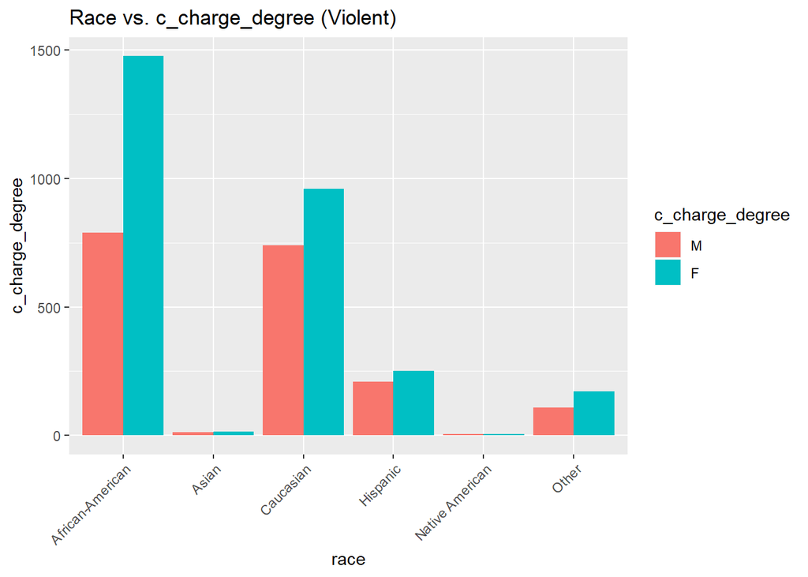

```r
vrace_c_plot = ggplot(data = vrace_c_sum, aes(x = race, y = Count, fill = c_charge_degree)) +
  geom_bar(stat = "identity", position = "dodge") +
  labs(title = "Race vs. c_charge_degree (Violent)", x = "race", y = "c_charge_degree") +
  theme(axis.text.x = element_text(angle = 45, vjust = 1, hjust = 1))

vrace_c_plot
```

African-Americans had a higher percentage of felonies than the other racial groups.

###### Sex vs. c_charge_degree

```r
vsex_c_sum <- raw.score.violent.df %>%
  group_by(sex, c_charge_degree) %>%
  summarize(Count = n())
```

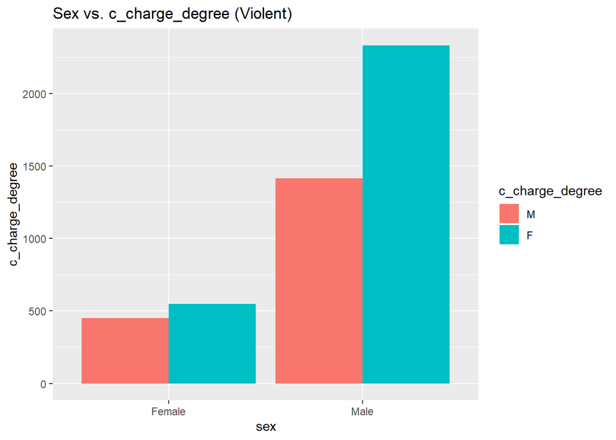

```r
vsex_c_plot = ggplot(data = vsex_c_sum, aes(x = sex, y = Count, fill = c_charge_degree)) +
  geom_bar(stat = "identity", position = "dodge") +
  labs(title = "Sex vs. c_charge_degree (Violent)", x = "sex", y = "c_charge_degree")

vsex_c_plot
```

Males had a higher percentage of felonies than females.

On the whole, most of the violent cases have a similar spread to the non-violent cases, barring the relationship between some demographic information and recidivism and the relationship between charge degree and recidivism.

Now we’ll turn to modeling recidivism.

**3. Modelling**

**3.1 General Recidivism**

**3.11 Logistic Regression**

## Model Formation

```r
general.fit <- glm(is_recid ~ ., family = "binomial", data = raw.score.df)

# summary(general.fit)
##which factors show statistical significance

general.summary <- coef(summary(general.fit))[,'Pr(>|z|)']
names(general.summary[general.summary<= .05])
```

```
##  [1] "sexFemale"              "age_cat25 - 45"
##  [3] "age_catGreater than 45" "raceCaucasian"
##  [5] "raceHispanic"           "raceOther"
##  [7] "juv_fel_count"          "juv_misd_count"
##  [9] "juv_other_count"        "priors_count"
## [11] "c_charge_degreeF"       "stay"
```

According to the logistic regression, it appears that gender, age category, race, charge, and prior history (juv count, priors count, length of time in jail, and charge degree) are statistically related to whether someone is recidivated.

## Evaluate most important variables

```r
#find best subset
set.seed(150)
subset.data <- raw.score.df[sample(nrow(raw.score.df), 3607), ]
raw.data.subset <- regsubsets(is_recid ~ .,
                              data = subset.data,
                              nbest = 1,
                              nvmax = NULL,
                              method = "forward", really.big = TRUE)
```

BIC test was chosen since we have only very few predictors

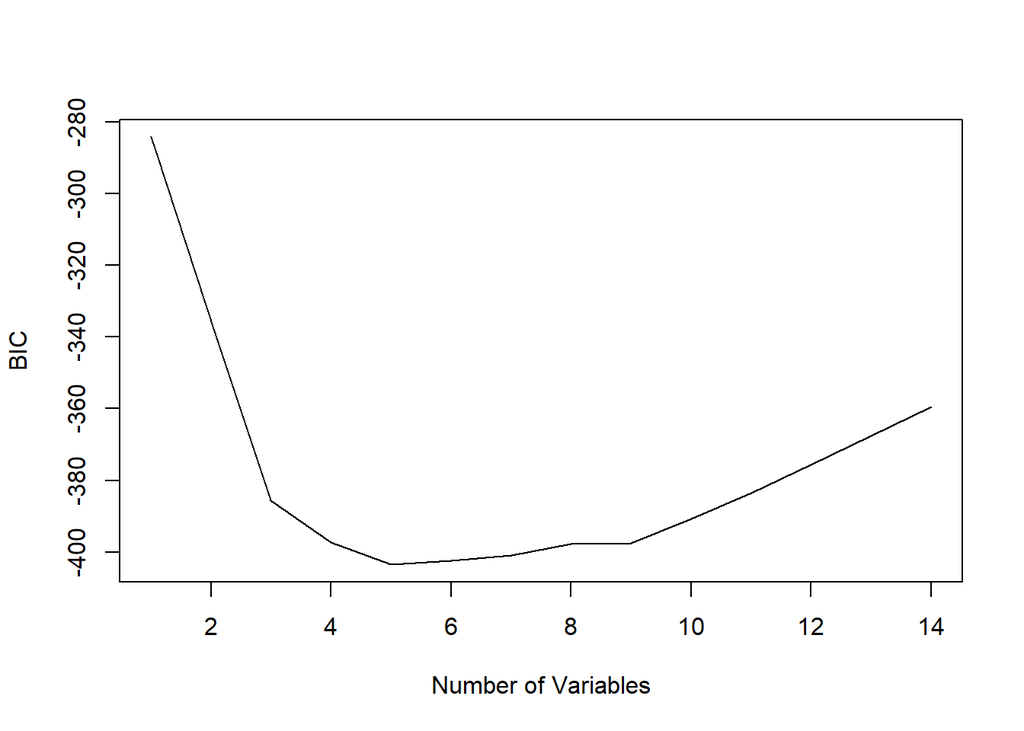

```r
# Run BIC test
BIC.summary <- summary(raw.data.subset)
plot(BIC.summary$bic, xlab  = "Number of Variables", ylab = "BIC", type = "l")
```

```r
print(names(coef(raw.data.subset, id = which.min(BIC.summary$bic))))
```

```
## [1] "(Intercept)"            "sexFemale"
## [3] "age_cat25 - 45"         "age_catGreater than 45"
## [5] "priors_count"           "stay"
```

```r
# sex, age_cat, juv_other_count, priors_count, c_charge_degree, stay
```

## Prediction with Logistic Regression

```r
log.fit <- glm(is_recid ~ ., family = "binomial", data = raw.score.df.train)
glm.predict <- predict(log.fit, newdata = raw.score.df.test, type = "response")

glm.conf.nv <- confusionMatrix(data = as.factor(ifelse(glm.predict > 0.5, 1, 0)),
                reference = as.factor(raw.score.df.test$is_recid),
                dnn = c("Prediction", "Reference"))
glm.conf.nv
```

```
## Confusion Matrix and Statistics
##
##           Reference
## Prediction    0    1
##          0    0    1
##          1  734 3708
##
##                Accuracy : 0.8346
##                  95% CI : (0.8233, 0.8454)
##     No Information Rate : 0.8348
##     P-Value [Acc > NIR] : 0.5259
##
##                   Kappa : -4e-04
##
##  Mcnemar's Test P-Value : <2e-16
##
##             Sensitivity : 0.0000000
##             Specificity : 0.9997304
##          Pos Pred Value : 0.0000000
##          Neg Pred Value : 0.8347591
##              Prevalence : 0.1652037
##          Detection Rate : 0.0000000
##    Detection Prevalence : 0.0002251
##       Balanced Accuracy : 0.4998652
##
##        'Positive' Class : 0
##
```

Our logistic regression shows a high classification rate of 83.46%. However, it has predicted relately accurately those who those are likely to be recidivated, but also has a high specificity. This means that it is grouping those who are likely to be recidivated though that might not be true.

## ROC Curve

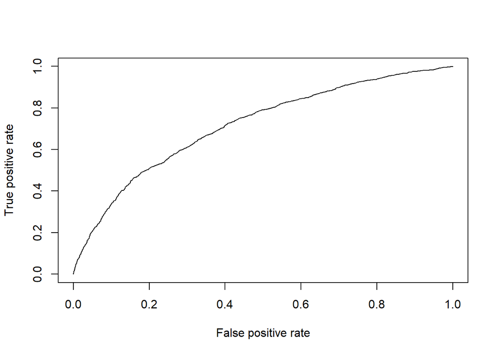

```r
predicts <- predict(log.fit, type = 'response')
ROCRpred <- prediction(predicts, raw.score.df.train$is_recid)
ROCRperf <- performance(ROCRpred, 'tpr', 'fpr')
plot(ROCRperf)
```

The ROC curve shows that achieving a very high true positive rate a very low false positive rate is very unlikely.

**3.12 LDA**

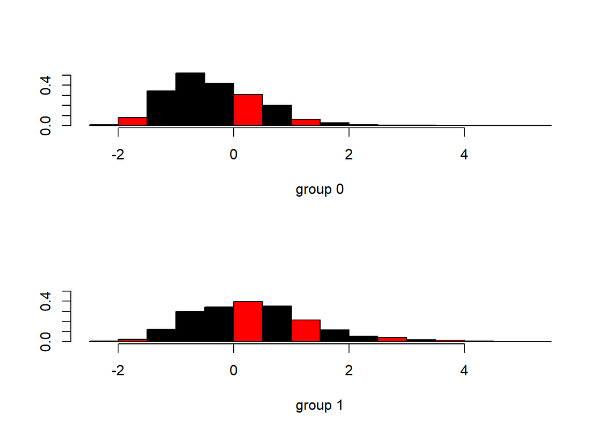

```r
lda.fit <- lda(is_recid ~ ., data = raw.score.df.train)

plot(lda.fit, col = as.numeric(raw.score.df.train$is_recid))
```

```r
lda.predict <- predict(lda.fit, newdata = raw.score.df.test)
lda.conf <- confusionMatrix(data = as.factor(lda.predict$class),
                reference = as.factor(raw.score.df.test$is_recid),
                dnn = c("Prediction", "Reference"))
lda.conf
```

```
## Confusion Matrix and Statistics
##
##           Reference
## Prediction    0    1
##          0    0    1
##          1  734 3708
##
##                Accuracy : 0.8346
##                  95% CI : (0.8233, 0.8454)
##     No Information Rate : 0.8348
##     P-Value [Acc > NIR] : 0.5259
##
##                   Kappa : -4e-04
##
##  Mcnemar's Test P-Value : <2e-16
##
##             Sensitivity : 0.0000000
##             Specificity : 0.9997304
##          Pos Pred Value : 0.0000000
##          Neg Pred Value : 0.8347591
##              Prevalence : 0.1652037
##          Detection Rate : 0.0000000
##    Detection Prevalence : 0.0002251
##       Balanced Accuracy : 0.4998652
##
##        'Positive' Class : 0
##
```

**3.13 QDA**

```r
qda.fit <- qda(is_recid ~ ., data = raw.score.df.train)

qda.predict <- predict(qda.fit, newdata = raw.score.df.test)
qda.conf <- confusionMatrix(data = as.factor(qda.predict$class),
                reference = as.factor(raw.score.df.test$is_recid),
                dnn = c("Prediction", "Reference"))
qda.conf
```

```
## Confusion Matrix and Statistics
##
##           Reference
## Prediction    0    1
##          0  644 2342
##          1   90 1367
##
##                Accuracy : 0.4526
##                  95% CI : (0.4379, 0.4674)
##     No Information Rate : 0.8348
##     P-Value [Acc > NIR] : 1
##
##                   Kappa : 0.1103
##
##  Mcnemar's Test P-Value : <2e-16
##
##             Sensitivity : 0.8774
##             Specificity : 0.3686
##          Pos Pred Value : 0.2157
##          Neg Pred Value : 0.9382
##              Prevalence : 0.1652
##          Detection Rate : 0.1449
##    Detection Prevalence : 0.6721
##       Balanced Accuracy : 0.6230
##
##        'Positive' Class : 0
##
```

Classification rate achieved for this is 45.26%, which is very low compared to the classification rate achieved to LDA and Logistic Regression. This model seems to have a tendency to classify more people as not likely to commit recidivism, which is the opposite of what we have observed so far.

**3.14 Naive Bayes**

```r
nb.fit <- NaiveBayes(is_recid ~ ., data = raw.score.df.train)

nb.predict <- predict(nb.fit, newdata = raw.score.df.test)
nb.conf <- confusionMatrix(data = as.factor(nb.predict$class),
                reference = as.factor(raw.score.df.test$is_recid),
                dnn = c("Prediction", "Reference"))
nb.conf
```

```
## Confusion Matrix and Statistics
##
##           Reference
## Prediction    0    1
##          0  647 2444
##          1   87 1265
##
##                Accuracy : 0.4303
##                  95% CI : (0.4157, 0.4451)
##     No Information Rate : 0.8348
##     P-Value [Acc > NIR] : 1
##
##                   Kappa : 0.0973
##
##  Mcnemar's Test P-Value : <2e-16
##
##             Sensitivity : 0.8815
##             Specificity : 0.3411
##          Pos Pred Value : 0.2093
##          Neg Pred Value : 0.9357
##              Prevalence : 0.1652
##          Detection Rate : 0.1456
##    Detection Prevalence : 0.6957
##       Balanced Accuracy : 0.6113
##
##        'Positive' Class : 0
##
```

Naive Bayes has a classification rate of 43.03%, which is low compared to the other models before. This definitely makes sense since Naive Bayes assumes independence and this dataset has a lot of factors that are very likely to be related to one another.

**3.15 Tree**

Next, we turn to classification trees to model our data.

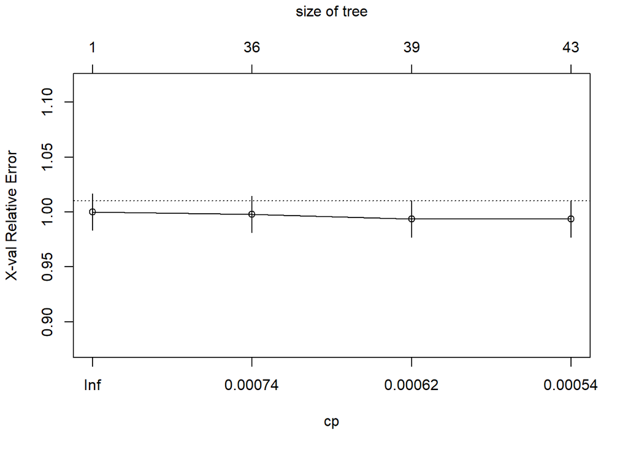

```r
#making a full tree
tree.full <- rpart(is_recid ~ ., data = raw.score.df.train,
                       control = rpart.control(minsplit=50, cp=0.0005))
plotcp(tree.full)
```

```r
tree.full$cptable
```

```
##             CP nsplit rel error    xerror       xstd
## 1 0.0008308408      0 1.0000000 1.0000000 0.01661520
## 2 0.0006646726     35 0.9544699 0.9980060 0.01660200
## 3 0.0005815886     38 0.9524759 0.9936856 0.01657331
## 4 0.0005000000     42 0.9501496 0.9936856 0.01657331
```

[figure not shown]

```r
tree.full.party <- as.party(tree.full)
plot(tree.full.party)
```

```r
print(tree.full.party)
```

```
##
## Model formula:
## is_recid ~ sex + age_cat + race + juv_fel_count + juv_misd_count +
##     juv_other_count + priors_count + c_charge_degree + stay
##
## Fitted party:
## [1] root
## |   [2] priors_count < 1.5
## |   |   [3] age_cat in 25 - 45, Greater than 45
## |   |   |   [4] stay < 4.5
## |   |   |   |   [5] sex in Female
## |   |   |   |   |   [6] stay < 1.5
## |   |   |   |   |   |   [7] race in Native American, Other: 0 (n = 36, err = 36.1%)
## |   |   |   |   |   |   [8] race in African-American, Caucasian, Hispanic
## |   |   |   |   |   |   |   [9] c_charge_degree in M
## |   |   |   |   |   |   |   |   [10] priors_count >= 0.5
## |   |   |   |   |   |   |   |   |   [11] race in African-American, Hispanic: 0 (n = 25, err = 28.0%)
## |   |   |   |   |   |   |   |   |   [12] race in Caucasian: 1 (n = 44, err = 45.5%)
## |   |   |   |   |   |   |   |   [13] priors_count < 0.5
## |   |   |   |   |   |   |   |   |   [14] race in Caucasian
## |   |   |   |   |   |   |   |   |   |   [15] stay >= 0.5: 0 (n = 72, err = 37.5%)
## |   |   |   |   |   |   |   |   |   |   [16] stay < 0.5: 1 (n = 50, err = 44.0%)
## |   |   |   |   |   |   |   |   |   [17] race in African-American, Hispanic: 1 (n = 107, err = 41.1%)
## |   |   |   |   |   |   |   [18] c_charge_degree in F
## |   |   |   |   |   |   |   |   [19] race in African-American
## |   |   |   |   |   |   |   |   |   [20] priors_count < 0.5: 0 (n = 38, err = 31.6%)
## |   |   |   |   |   |   |   |   |   [21] priors_count >= 0.5: 1 (n = 53, err = 41.5%)
## |   |   |   |   |   |   |   |   [22] race in Caucasian, Hispanic: 1 (n = 139, err = 31.7%)
## |   |   |   |   |   [23] stay >= 1.5
## |   |   |   |   |   |   [24] age_cat in Greater than 45
## |   |   |   |   |   |   |   [25] race in African-American, Other: 0 (n = 23, err = 30.4%)
## |   |   |   |   |   |   |   [26] race in Caucasian, Hispanic: 1 (n = 29, err = 27.6%)
## |   |   |   |   |   |   [27] age_cat in 25 - 45: 1 (n = 118, err = 22.0%)
## |   |   |   |   [28] sex in Male
## |   |   |   |   |   [29] priors_count < 0.5
## |   |   |   |   |   |   [30] race in Asian, Hispanic, Other
## |   |   |   |   |   |   |   [31] stay < 2.5
## |   |   |   |   |   |   |   |   [32] age_cat in 25 - 45
## |   |   |   |   |   |   |   |   |   [33] stay < 1.5
## |   |   |   |   |   |   |   |   |   |   [34] race in Asian, Hispanic: 0 (n = 87, err = 41.4%)
```

[output cut: 39 more lines]

```
## |   |   |   |   |   |   [74] stay >= 10: 1 (n = 19, err = 21.1%)
## |   |   |   |   [75] race in African-American, Hispanic: 1 (n = 349, err = 23.2%)
## |   |   |   [76] sex in Male: 1 (n = 2365, err = 16.2%)
## |   [77] priors_count >= 1.5
## |   |   [78] priors_count < 5.5
## |   |   |   [79] stay < 0.5
## |   |   |   |   [80] age_cat in Greater than 45
## |   |   |   |   |   [81] priors_count < 2.5: 0 (n = 45, err = 42.2%)
## |   |   |   |   |   [82] priors_count >= 2.5: 1 (n = 116, err = 32.8%)
## |   |   |   |   [83] age_cat in Less than 25, 25 - 45: 1 (n = 502, err = 20.9%)
## |   |   |   [84] stay >= 0.5: 1 (n = 5028, err = 12.2%)
## |   |   [85] priors_count >= 5.5: 1 (n = 5099, err = 6.7%)
##
## Number of inner nodes:    42
## Number of terminal nodes: 43
```